# Prediction_Assignment

Mingda Wang

Jun 7 2018

## Project Goal

The goal of your project is to predict the manner in which they did the exercise. This is the “classe” variable in the training set. You may use any of the other variables to predict with. You should create a report describing how you built your model, how you used cross validation, what you think the expected out of sample error is, and why you made the choices you did. You will also use your prediction model to predict 20 different test cases.

## Synopsis

In this project, I will explore the given dataset, and apply classfication algorithm on the data. After testing with both decision tree and random forest algorithm with repeated cross validation and cross validation. The accuracy for random forest is over 99% when inlucding all variables, and 98% when only including variables that has a correlation higher than median correlation. Eventually, I have made predictions toward the grading dataset using random forest.

## Load Dataset

Load both training and testing dataset from csv, and remove the rownames column.

```r
pmlTrain <- read.csv("pml-training.csv", sep=",")
pmlTrain <- pmlTrain[,-1]
pmlTest <- read.csv("pml-testing.csv", sep=",")
pmlTest <- pmlTest[,-1]
```

## Dataset Processing

By looking at the pmlTest dataset, we immediatly notice some of the columns have most NAs in them. We would like to set a threshold that if over 95% of values in the columns are NAs, we will not include these variables when making our model. Although we can impute the value based on the avg value of the subject, it is unnecessary to include them when new data having NA values in them.

```r
threshold <- 0.95 * nrow(pmlTrain)
noNATrain <- pmlTrain[,colSums(is.na(pmlTrain)) < threshold]
```

In addition, we will remove variables that has almost no variance. These variables are not useful as the values are most static in those columns. We will also remove variables such as timestamp and username.

```r
nzvCols <- nearZeroVar(noNATrain)
training <- noNATrain[,-nzvCols]

training <- training[,-grep("timestamp", colnames(training))]
training <- training[,-1]
```

Now, we have a finalized training dataset that contains only the variables needed. We will now subset our pmlTest dataset to include only variables in our finalized training dataset.

```r
colsNeeded <- colnames(training)
gradeTesting <- pmlTest[,which(colnames(pmlTest) %in% colsNeeded)]
gradeTesting$problem_id <- pmlTest$problem_id
```

## Create Model Training & Testing Dataset

This will split the previously cleaned up training data into 2 groups based on classe variable in the training dataset. The modelTrain dataset will include 60% of the total data in training while the modelTest dataset will include the rest 40%.

```r
set.seed(11211)

inTrain <- createDataPartition(training$classe, p=0.6, list=FALSE)
modelTrain <- training[inTrain,]
modelTest <- training[-inTrain,]
```

## Correlation Analysis

Since classe data is not a continous variable, we cannot use pearson correlation. Therefore, we will use the hector function in the polycor library. The hector will utilize pearson for continous to continous, polychoric for nominal to nominal, and polyserial for nominal to continous correlations

```r
corAnalysis <- suppressWarnings(hetcor(modelTrain$classe,modelTrain[,-54]))
corVal <- abs(corAnalysis$correlations[1,])
corType <- corAnalysis$type[1,]

corDF <- data.frame("Correlation Strength Absolute" = corVal,
                    "Correlation Type" = corType)

corDF <- corDF[order(-corDF[,"Correlation.Strength.Absolute"]),]
print(corDF)
```

```
##                      Correlation.Strength.Absolute Correlation.Type
## modelTrain$classe                     1.0000000000
## pitch_forearm                         0.3946419992       Polyserial
## magnet_arm_x                          0.3218400470       Polyserial
## magnet_belt_y                         0.3132620342       Polyserial
## magnet_arm_y                          0.2777378848       Polyserial
## accel_arm_x                           0.2614073924       Polyserial
## pitch_arm                             0.2005329570       Polyserial
## magnet_forearm_x                      0.1980513946       Polyserial
## magnet_belt_z                         0.1935396021       Polyserial
## accel_forearm_x                       0.1931368506       Polyserial
## magnet_arm_z                          0.1774673642       Polyserial
## total_accel_forearm                   0.1755691742       Polyserial
## magnet_dumbbell_z                     0.1725314555       Polyserial
## accel_dumbbell_x                      0.1403481813       Polyserial
## total_accel_arm                       0.1244753170       Polyserial
## magnet_forearm_y                      0.1212625417       Polyserial
## roll_arm                              0.1159003247       Polyserial
## pitch_dumbbell                        0.1045314560       Polyserial
## accel_arm_y                           0.0860726411       Polyserial
## magnet_dumbbell_x                     0.0828416343       Polyserial
## accel_dumbbell_z                      0.0827534048       Polyserial
## accel_belt_z                          0.0804657682       Polyserial
## total_accel_belt                      0.0762245328       Polyserial
## roll_belt                             0.0632515143       Polyserial
## yaw_arm                               0.0614275720       Polyserial
## gyros_dumbbell_y                      0.0531364562       Polyserial
## roll_dumbbell                         0.0435605702       Polyserial
## magnet_forearm_z                      0.0427270135       Polyserial
## yaw_forearm                           0.0422239218       Polyserial
## accel_arm_z                           0.0373493834       Polyserial
## roll_forearm                          0.0364622099       Polyserial
## total_accel_dumbbell                  0.0358459714       Polyserial
## gyros_belt_y                          0.0337713538       Polyserial
## magnet_belt_x                         0.0242865506       Polyserial
## gyros_arm_y                           0.0230310844       Polyserial
## gyros_forearm_x                       0.0214436074       Polyserial
## accel_forearm_y                       0.0196018712       Polyserial
## gyros_belt_x                          0.0186179250       Polyserial
## gyros_dumbbell_z                      0.0183457900       Polyserial
## accel_belt_x                          0.0144146727       Polyserial
## gyros_dumbbell_x                      0.0137997292       Polyserial
## gyros_belt_z                          0.0137995222       Polyserial
## yaw_belt                              0.0119839981       Polyserial
## yaw_dumbbell                          0.0101243452       Polyserial
## gyros_forearm_z                       0.0098411863       Polyserial
## accel_belt_y                          0.0093692480       Polyserial
## num_window                            0.0076089636       Polyserial
## gyros_arm_z                           0.0069041167       Polyserial
## gyros_arm_x                           0.0056130053       Polyserial
## pitch_belt                            0.0043013012       Polyserial
## gyros_forearm_y                       0.0037075672       Polyserial
## accel_forearm_z                       0.0030673113       Polyserial
## magnet_dumbbell_y                     0.0020936231       Polyserial
## accel_dumbbell_y                      0.0002621574       Polyserial
```

The above dataframe shows the correlations strength between classe and rest variables in descending order.

## Prediction Models

Firstly, we will run few models against all variables in the modelTrain dataset. Then, we can investigate on using only subset of those data based on our correlation analysis.

### Decision Tree with rPart

#### All Variables Included

```r
dtAllModel <- suppressWarnings(train(classe~.,
                                     data=modelTrain,
                                     method="rpart",
                                     tuneLength = 50,
                                     metric="Accuracy",
                                     trControl = trainControl(method = "repeatedcv",
                                                              number = 5,
                                                              repeats = 5,
                                                              summaryFunction = multiClassSummary,
                                                              classProbs = TRUE)))

dtAllPredTest <- predict(dtAllModel, modelTest)
```

##### Model Accuracy for Test Data:

```r
cmDtAllModel <- confusionMatrix(dtAllPredTest,modelTest$classe)
print(cmDtAllModel$table)
```

```
##           Reference
## Prediction    A    B    C    D    E
##          A 2135   69    2   13    2
##          B   46 1312   81   37   55
##          C   19   73 1188   49   30
##          D   16   28   58 1157   41
##          E   16   36   39   30 1314
```

```r
print(paste("Accuracy", cmDtAllModel$overall[1]))
```

```
## [1] "Accuracy 0.905684425184808"
```

#### Only More Correlated Variables Included

```r
upperMedianVars <- rownames(corDF[corDF$Correlation.Strength.Absolute > median(corDF$Correlation.Strength.Absolute),])

upperMedianVars[1] <- "classe"
```

This returns variables that is more correlated than median correlation in the correlation strength.

```r
selectedVarTrain <- modelTrain[,upperMedianVars]
selectedVarTest <- modelTest[,upperMedianVars]

dtCorVarModel <- suppressWarnings(train(classe~.,
                                     data=selectedVarTrain,
                                     method="rpart",
                                     tuneLength = 50,
                                     metric="Accuracy",
                                     trControl = trainControl(method = "repeatedcv",
                                                              number = 5,
                                                              repeats = 5,
                                                              summaryFunction = multiClassSummary,
                                                              classProbs = TRUE)))
dtCorVarModelPredTest <- predict(dtCorVarModel, selectedVarTest)
```

##### Model Accuracy for Test Data:

```r
cmDtCorVarModel <- confusionMatrix(dtCorVarModelPredTest,selectedVarTest$classe)
print(cmDtCorVarModel$table)
```

```
##           Reference
## Prediction    A    B    C    D    E
##          A 2043   97   28   51   23
##          B   74 1254  148   36   41
##          C   32   71 1133   86   42
##          D   66   71   52 1093   26
##          E   17   25    7   20 1310
```

```r
print(paste("Accuracy", cmDtCorVarModel$overall[1]))
```

```
## [1] "Accuracy 0.87088962528677"
```

From this, we can see there is a around 3% accuracy reduction from using all variables. However, we have only included half of the predictors. Not only the modelling speed is faster, but the results are not too much off from using all results.

#### Confusion Matrix Plots

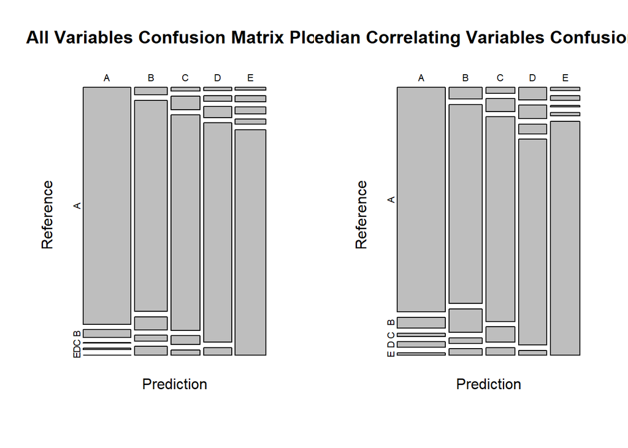

```r
par(mfrow=c(1,2))

plot(cmDtAllModel$table, main="All Variables Confusion Matrix Plot")
plot(cmDtCorVarModel$table, main="Upper Median Correlating Variables Confusion Matrix Plot")
```

### Random Forest Modelling

The accuracy for deicsion tree is pretty high, but I would like to try random forest, and see if that will increase our accuracy even higher.

#### Random Forest for All Vairables

```r
rfAllModel <- suppressWarnings(train(classe~.,
                                     data=modelTrain,
                                     method="rf",
                                     trControl = trainControl(
                                       method = "cv",
                                       number = 5)))

rfAllPredTest <- predict(rfAllModel, modelTest)
```

##### Model Accuracy for Test Data:

```r
cmRfAllModel <- confusionMatrix(rfAllPredTest,modelTest$classe)
print(cmRfAllModel$table)
```

```
##           Reference
## Prediction    A    B    C    D    E
##          A 2231    7    0    0    0
##          B    0 1509    3    0    0
##          C    0    2 1365    2    0
##          D    0    0    0 1284    7
##          E    1    0    0    0 1435
```

```r
print(paste("Accuracy", cmRfAllModel$overall[1]))
```

```
## [1] "Accuracy 0.99719602345144"
```

#### Random Forest for Upper Median Correlated Vairables

```r
rfCorVarModel <- suppressWarnings(train(classe~.,
                                     data=selectedVarTrain,
                                     method="rf",
                                     trControl = trainControl(
                                       method = "cv",
                                       number = 5)))

rfCorVarModelPredTest <- predict(rfCorVarModel, selectedVarTest)
```

##### Model Accuracy for Test Data:

```r
cmRfCorVarModel <- confusionMatrix(rfCorVarModelPredTest,selectedVarTest$classe)
print(cmRfCorVarModel$table)
```

```
##           Reference
## Prediction    A    B    C    D    E
##          A 2218   20    0    3    0
##          B    8 1483   26    0    4
##          C    1   13 1337   37    2
##          D    5    2    5 1246   15
##          E    0    0    0    0 1421
```

```r
print(paste("Accuracy", cmRfCorVarModel$overall[1]))
```

```
## [1] "Accuracy 0.982029059393321"
```

#### Confusion Matrix Plots

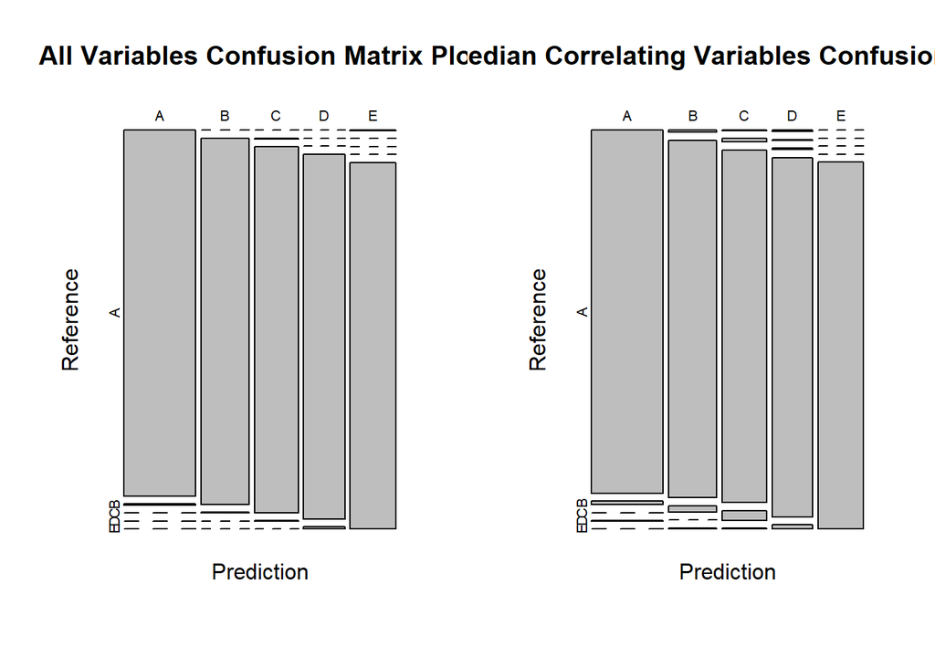

```r
par(mfrow=c(1,2))

plot(cmRfAllModel$table, main="All Variables Confusion Matrix Plot")
plot(cmRfCorVarModel$table, main="Upper Median Correlating Variables Confusion Matrix Plot")
```

We can see that random forest model has a much higher prediction accuracy than rpart model. Also, at both times, less variables yields a minor reduction in accuract, but a much faster processing time.

## Getting Prediction for Grading Data

```r
gradingPrediction <- predict(rfAllModel, gradeTesting)

print(data.frame(
  "problem_id" = gradeTesting$problem_id,
  "prediction" = gradingPrediction
))
```

```
##    problem_id prediction
## 1           1          B
## 2           2          A
## 3           3          B
## 4           4          A
## 5           5          A
## 6           6          E
## 7           7          D
## 8           8          B
## 9           9          A
## 10         10          A
## 11         11          B
## 12         12          C
## 13         13          B
## 14         14          A
## 15         15          E
## 16         16          E
## 17         17          A
## 18         18          B
## 19         19          B
## 20         20          B
```